# COVID-19 US Weekly Forecast Summary

[The COVID-19 Forecast Hub Team](https://covid19forecasthub.org/doc/) https://covid19forecasthub.org/

report generated 2022-03-08

# Background

This report provides a brief summary of the weekly ensemble forecast from the [COVID-19 Forecast Hub](https://covid19forecasthub.org/) based on forecasts submitted on March 07, 2022. In collaboration with the US CDC, our team aggregates COVID-19 forecasts from dozens of teams around the globe. Typically on Wednesday of each week, a summary of the week's forecasts from the COVID-19 Forecast Hub appear on the [official CDC COVID-19 forecasting page](https://www.cdc.gov/coronavirus/2019-ncov/covid-data/forecasting-us.html).

Every week, teams submit their forecasts to the COVID-19 Forecast Hub. This past week, 43 models were submitted.

Each Monday evening or Tuesday morning, we combine the most recent forecasts from each team into a single "ensemble" forecast of reported COVID-19 cases at the county, state, and national level and deaths at the state and national level. At the moment, we only generate ensemble forecasts for up to four weeks into the future, as [the available evidence](https://www.medrxiv.org/content/10.1101/2021.02.03.21250974v1) suggests that models are less accurate at longer forecast horizons.

An archive of weekly reports from the COVID-19 Forecast Hub can be found at [this page](https://covid19forecasthub.org/doc/reports/).

# COVID-19 Forecasts

## National level

This week, our ensemble combined forecasts from 34 different models.

At the national level, the ensemble model predicts that weekly totals of observed deaths in each of the next four weeks will be between 4,400 and 8,700 deaths with around 980,400 deaths by April 02, 2022 (95% prediction interval: 973,552 - 987,980).

For the week ending April 02, 2022, the ensemble forecasts that reported COVID-19 deaths in the US will be between 2,500 and 6,100 (95% prediction interval: 2,463 - 6,121).

As of September 28, 2021 the ensemble forecast only reports one-week ahead forecasts for cases and 14 day ahead forecasts for hospitalizations, due to persistent large inaccuracies observed when forecasting beyond that.

For March 21, 2022 COVID-19 daily hospitalizations in the US will be between 800 and 5,600 (95% prediction interval: 823 - 5,554).

For the week ending March 12, 2022, the ensemble forecasts that reported COVID-19 cases in the US will be between 113,800 and 414,600 (95% prediction interval: 113,792 - 414,631).

You can explore the full set of models, including their forecasts for past weeks online at the [Forecast Hub interactive visualization](https://viz.covid19forecasthub.org/).

### Deaths

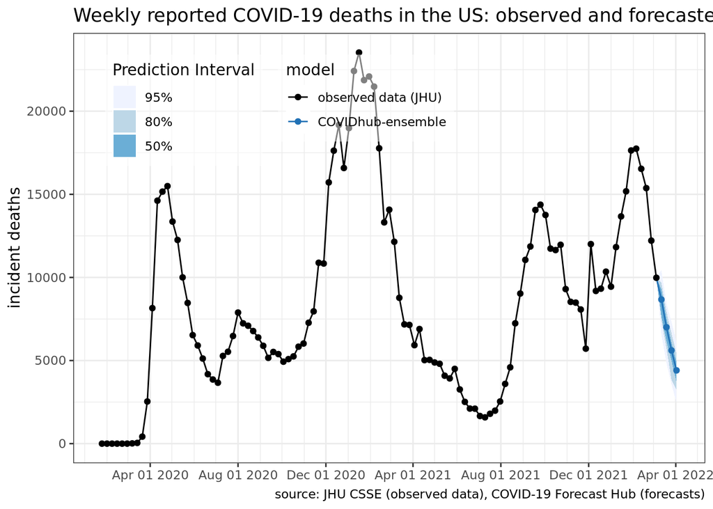

### Hospitalizations

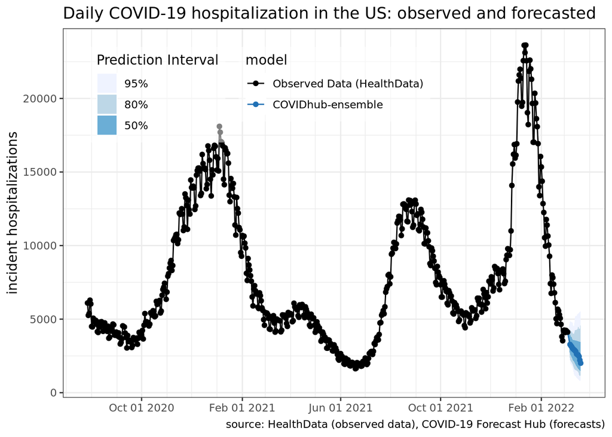

### Cases

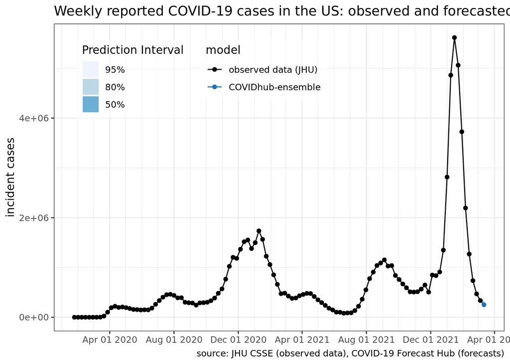

## State level

The ensemble model estimates that 3 out of 50 states and 2 out of 7 territories of the US have a greater than 50% chance of having more deaths in the next two weeks compared to the past two weeks.The model forecasts that 3 states and territories have a greater than 75% chance of an increase over the next two weeks (Arizona, North Dakota, American Samoa).

The sortable and searchable table below shows the total number of reported COVID-19 deaths at the US level and by state over the last two weeks (ending Saturday, March 05, 2022) and the forecasted counts for the subsequent two weeks (ending March 19, 2022).

| state | Population | Total COVID-19 deaths | COVID-19 deaths, last 2 weeks | COVID-19 deaths, next 2 weeks | Difference |
| --- | --- | --- | --- | --- | --- |
| Arizona | 7278717 | 27708 | 195 | 338 | 143 |
| North Dakota | 762062 | 2211 | -10 | 17 | 27 |
| Kansas | 2913314 | 7983 | 78 | 86 | 8 |
| Guam | 164229 | 331 | 15 | 16 | 1 |
| American Samoa | 55641 | 0 | 0 | 0 | 0 |
| District of Columbia | 705749 | 1319 | 5 | 4 | -1 |
| Ohio | 11689100 | 37018 | 232 | 231 | -1 |
| Virgin Islands | 107268 | 109 | 1 | 0 | -1 |
| Vermont | 623989 | 607 | 24 | 22 | -2 |
| Northern Mariana Islands | 55144 | 30 | 5 | 2 | -3 |

[output cut: 47 more lines]

Looking at the rates allows for easier comparison across states, where you can see which states have had or are predicted to have proportionally higher rates in comparison to other states.

When interpreting probability of an increase, it's important to note that the increase or decrease is relative to the location-specific recent observed incidence, which varies across locations.

### Death rates

The sortable and searchable death table below shows the total number of reported COVID-19 deaths at the US level and by state as of Saturday, March 05, 2022 ("Total COVID-19 Deaths") as well as the rate of reported COVID-19 deaths in the population (standardized per 100,000 population) over the last two weeks and over the next two weeks.

| state | Population | Total COVID-19 deaths | Daily deaths per 100k, last 2 weeks | Daily deaths per 100k, next 2 weeks | Death rate difference |
| --- | --- | --- | --- | --- | --- |
| North Dakota | 762062 | 2211 | -0.094 | 0.159 | 0.253 |
| Arizona | 7278717 | 27708 | 0.191 | 0.332 | 0.141 |
| Guam | 164229 | 331 | 0.652 | 0.696 | 0.044 |
| Kansas | 2913314 | 7983 | 0.191 | 0.211 | 0.02 |
| American Samoa | 55641 | 0 | 0 | 0 | 0 |
| Ohio | 11689100 | 37018 | 0.142 | 0.141 | -0.001 |
| District of Columbia | 705749 | 1319 | 0.051 | 0.04 | -0.011 |
| Idaho | 1787065 | 4788 | 0.448 | 0.432 | -0.016 |
| New Hampshire | 1359711 | 2377 | 0.231 | 0.21 | -0.021 |
| Vermont | 623989 | 607 | 0.275 | 0.252 | -0.023 |

[output cut: 47 more lines]

### Hospitalization rates

The sortable and searchable hospitalization table below shows the 7 day average hospitalization count and rate of reported COVID-19 hospitalization in the population (standardized per 100,000 population) over the last week (February 27, 2022 to March 05, 2022) and two weeks ahead (March 13, 2022 to March 19, 2022).

[interactive table not shown]

### Case rates

The sortable and searchable case table below shows the weekly case count and rate of reported COVID-19 case in the population (standardized per 100,000 population) over the last week (February 27, 2022 to March 05, 2022) and one week ahead (March 06, 2022 to March 12, 2022).

[interactive table not shown]

# Methods & Acknowledgement

This report was reproducibly and dynamically generated using RMarkdown. The code for the report can be found [here](https://github.com/reichlab/covid19-forecast-hub/tree/master/code/reports).